# Risk Factor Analysis

## Outcome Variable

**Outcome Variable:** ever_co

## Predictor Variables

**Intervention Variable:** impsan

**Adjustment Set:**

- arm
- sex
- W_mage
- meducyrs
- feducyrs
- hhwealth_quart
- hfoodsec
- W_mhtcm
- W_nrooms
- W_nchldlt5
- W_parity
- impfloor
- safeh20
- delta_W_mage
- delta_meducyrs
- delta_feducyrs
- delta_hhwealth_quart
- delta_hfoodsec
- delta_W_mhtcm
- delta_W_nrooms
- delta_W_nchldlt5
- delta_W_parity
- delta_impfloor
- delta_safeh20

## Stratifying Variables

The analysis was stratified on these variable(s):

- agecat
- studyid
- country

## Data Summary

| agecat | studyid | country | impsan | ever_co | n_cell | n |
| --- | --- | --- | --- | --- | --- | --- |
| 0-24 months | ki0047075b-MAL-ED | BANGLADESH | 1 | 0 | 171 | 242 |
| 0-24 months | ki0047075b-MAL-ED | BANGLADESH | 1 | 1 | 33 | 242 |
| 0-24 months | ki0047075b-MAL-ED | BANGLADESH | 0 | 0 | 32 | 242 |
| 0-24 months | ki0047075b-MAL-ED | BANGLADESH | 0 | 1 | 6 | 242 |
| 0-24 months | ki0047075b-MAL-ED | BRAZIL | 1 | 0 | 204 | 210 |
| 0-24 months | ki0047075b-MAL-ED | BRAZIL | 1 | 1 | 2 | 210 |
| 0-24 months | ki0047075b-MAL-ED | BRAZIL | 0 | 0 | 4 | 210 |
| 0-24 months | ki0047075b-MAL-ED | BRAZIL | 0 | 1 | 0 | 210 |
| 0-24 months | ki0047075b-MAL-ED | INDIA | 1 | 0 | 93 | 233 |
| 0-24 months | ki0047075b-MAL-ED | INDIA | 1 | 1 | 15 | 233 |
| 0-24 months | ki0047075b-MAL-ED | INDIA | 0 | 0 | 89 | 233 |
| 0-24 months | ki0047075b-MAL-ED | INDIA | 0 | 1 | 36 | 233 |
| 0-24 months | ki0047075b-MAL-ED | NEPAL | 1 | 0 | 214 | 236 |
| 0-24 months | ki0047075b-MAL-ED | NEPAL | 1 | 1 | 21 | 236 |
| 0-24 months | ki0047075b-MAL-ED | NEPAL | 0 | 0 | 1 | 236 |
| 0-24 months | ki0047075b-MAL-ED | NEPAL | 0 | 1 | 0 | 236 |
| 0-24 months | ki0047075b-MAL-ED | PERU | 1 | 0 | 60 | 263 |
| 0-24 months | ki0047075b-MAL-ED | PERU | 1 | 1 | 5 | 263 |
| 0-24 months | ki0047075b-MAL-ED | PERU | 0 | 0 | 192 | 263 |
| 0-24 months | ki0047075b-MAL-ED | PERU | 0 | 1 | 6 | 263 |
| 0-24 months | ki0047075b-MAL-ED | SOUTH AFRICA | 1 | 0 | 3 | 250 |
| 0-24 months | ki0047075b-MAL-ED | SOUTH AFRICA | 1 | 1 | 1 | 250 |
| 0-24 months | ki0047075b-MAL-ED | SOUTH AFRICA | 0 | 0 | 227 | 250 |
| 0-24 months | ki0047075b-MAL-ED | SOUTH AFRICA | 0 | 1 | 19 | 250 |
| 0-24 months | ki0047075b-MAL-ED | TANZANIA, UNITED REPUBLIC OF | 1 | 0 | 0 | 241 |
| 0-24 months | ki0047075b-MAL-ED | TANZANIA, UNITED REPUBLIC OF | 1 | 1 | 0 | 241 |
| 0-24 months | ki0047075b-MAL-ED | TANZANIA, UNITED REPUBLIC OF | 0 | 0 | 218 | 241 |
| 0-24 months | ki0047075b-MAL-ED | TANZANIA, UNITED REPUBLIC OF | 0 | 1 | 23 | 241 |
| 0-24 months | ki1017093-NIH-Birth | BANGLADESH | 1 | 0 | 196 | 624 |
| 0-24 months | ki1017093-NIH-Birth | BANGLADESH | 1 | 1 | 46 | 624 |

[output cut: 174 more lines]

The following strata were considered:

- agecat: 0-24 months, studyid: ki0047075b-MAL-ED, country: BANGLADESH
- agecat: 0-24 months, studyid: ki0047075b-MAL-ED, country: BRAZIL
- agecat: 0-24 months, studyid: ki0047075b-MAL-ED, country: INDIA
- agecat: 0-24 months, studyid: ki0047075b-MAL-ED, country: NEPAL
- agecat: 0-24 months, studyid: ki0047075b-MAL-ED, country: PERU
- agecat: 0-24 months, studyid: ki0047075b-MAL-ED, country: SOUTH AFRICA
- agecat: 0-24 months, studyid: ki0047075b-MAL-ED, country: TANZANIA, UNITED REPUBLIC OF
- agecat: 0-24 months, studyid: ki1017093-NIH-Birth, country: BANGLADESH
- agecat: 0-24 months, studyid: ki1017093b-PROVIDE, country: BANGLADESH
- agecat: 0-24 months, studyid: ki1017093c-NIH-Crypto, country: BANGLADESH
- agecat: 0-24 months, studyid: ki1114097-CONTENT, country: PERU
- agecat: 0-24 months, studyid: ki1135781-COHORTS, country: GUATEMALA
- agecat: 0-24 months, studyid: ki1135781-COHORTS, country: INDIA
- agecat: 0-24 months, studyid: ki1135781-COHORTS, country: PHILIPPINES
- agecat: 0-24 months, studyid: ki1148112-LCNI-5, country: MALAWI
- agecat: 0-24 months, studyid: kiGH5241-JiVitA-3, country: BANGLADESH
- agecat: 0-24 months, studyid: kiGH5241-JiVitA-4, country: BANGLADESH
- agecat: 0-6 months, studyid: ki0047075b-MAL-ED, country: BANGLADESH
- agecat: 0-6 months, studyid: ki0047075b-MAL-ED, country: BRAZIL
- agecat: 0-6 months, studyid: ki0047075b-MAL-ED, country: INDIA
- agecat: 0-6 months, studyid: ki0047075b-MAL-ED, country: NEPAL
- agecat: 0-6 months, studyid: ki0047075b-MAL-ED, country: PERU
- agecat: 0-6 months, studyid: ki0047075b-MAL-ED, country: SOUTH AFRICA
- agecat: 0-6 months, studyid: ki0047075b-MAL-ED, country: TANZANIA, UNITED REPUBLIC OF
- agecat: 0-6 months, studyid: ki1017093-NIH-Birth, country: BANGLADESH
- agecat: 0-6 months, studyid: ki1017093b-PROVIDE, country: BANGLADESH
- agecat: 0-6 months, studyid: ki1017093c-NIH-Crypto, country: BANGLADESH
- agecat: 0-6 months, studyid: ki1114097-CONTENT, country: PERU
- agecat: 0-6 months, studyid: ki1135781-COHORTS, country: GUATEMALA
- agecat: 0-6 months, studyid: ki1135781-COHORTS, country: INDIA
- agecat: 0-6 months, studyid: ki1135781-COHORTS, country: PHILIPPINES
- agecat: 0-6 months, studyid: ki1148112-LCNI-5, country: MALAWI
- agecat: 0-6 months, studyid: kiGH5241-JiVitA-3, country: BANGLADESH
- agecat: 0-6 months, studyid: kiGH5241-JiVitA-4, country: BANGLADESH
- agecat: 6-24 months, studyid: ki0047075b-MAL-ED, country: BANGLADESH
- agecat: 6-24 months, studyid: ki0047075b-MAL-ED, country: BRAZIL
- agecat: 6-24 months, studyid: ki0047075b-MAL-ED, country: INDIA
- agecat: 6-24 months, studyid: ki0047075b-MAL-ED, country: NEPAL
- agecat: 6-24 months, studyid: ki0047075b-MAL-ED, country: PERU
- agecat: 6-24 months, studyid: ki0047075b-MAL-ED, country: SOUTH AFRICA
- agecat: 6-24 months, studyid: ki0047075b-MAL-ED, country: TANZANIA, UNITED REPUBLIC OF
- agecat: 6-24 months, studyid: ki1017093-NIH-Birth, country: BANGLADESH
- agecat: 6-24 months, studyid: ki1017093b-PROVIDE, country: BANGLADESH
- agecat: 6-24 months, studyid: ki1017093c-NIH-Crypto, country: BANGLADESH
- agecat: 6-24 months, studyid: ki1114097-CONTENT, country: PERU
- agecat: 6-24 months, studyid: ki1135781-COHORTS, country: GUATEMALA
- agecat: 6-24 months, studyid: ki1135781-COHORTS, country: INDIA
- agecat: 6-24 months, studyid: ki1135781-COHORTS, country: PHILIPPINES
- agecat: 6-24 months, studyid: ki1148112-LCNI-5, country: MALAWI
- agecat: 6-24 months, studyid: kiGH5241-JiVitA-3, country: BANGLADESH
- agecat: 6-24 months, studyid: kiGH5241-JiVitA-4, country: BANGLADESH

### Dropped Strata

Some strata were dropped due to rare outcomes:

- agecat: 0-24 months, studyid: ki0047075b-MAL-ED, country: BRAZIL
- agecat: 0-24 months, studyid: ki0047075b-MAL-ED, country: NEPAL
- agecat: 0-24 months, studyid: ki0047075b-MAL-ED, country: SOUTH AFRICA
- agecat: 0-24 months, studyid: ki0047075b-MAL-ED, country: TANZANIA, UNITED REPUBLIC OF
- agecat: 0-24 months, studyid: ki1114097-CONTENT, country: PERU
- agecat: 0-24 months, studyid: ki1148112-LCNI-5, country: MALAWI
- agecat: 0-6 months, studyid: ki0047075b-MAL-ED, country: BANGLADESH
- agecat: 0-6 months, studyid: ki0047075b-MAL-ED, country: BRAZIL
- agecat: 0-6 months, studyid: ki0047075b-MAL-ED, country: NEPAL
- agecat: 0-6 months, studyid: ki0047075b-MAL-ED, country: PERU
- agecat: 0-6 months, studyid: ki0047075b-MAL-ED, country: SOUTH AFRICA
- agecat: 0-6 months, studyid: ki0047075b-MAL-ED, country: TANZANIA, UNITED REPUBLIC OF
- agecat: 0-6 months, studyid: ki1017093b-PROVIDE, country: BANGLADESH
- agecat: 0-6 months, studyid: ki1017093c-NIH-Crypto, country: BANGLADESH
- agecat: 0-6 months, studyid: ki1114097-CONTENT, country: PERU
- agecat: 0-6 months, studyid: ki1135781-COHORTS, country: GUATEMALA
- agecat: 0-6 months, studyid: ki1135781-COHORTS, country: PHILIPPINES
- agecat: 0-6 months, studyid: ki1148112-LCNI-5, country: MALAWI
- agecat: 6-24 months, studyid: ki0047075b-MAL-ED, country: BRAZIL
- agecat: 6-24 months, studyid: ki0047075b-MAL-ED, country: NEPAL
- agecat: 6-24 months, studyid: ki0047075b-MAL-ED, country: SOUTH AFRICA
- agecat: 6-24 months, studyid: ki0047075b-MAL-ED, country: TANZANIA, UNITED REPUBLIC OF
- agecat: 6-24 months, studyid: ki1114097-CONTENT, country: PERU
- agecat: 6-24 months, studyid: ki1148112-LCNI-5, country: MALAWI

## Methods Detail

We’re interested in the causal parameters $E[Y_a]$ for all values of $a \in \mathcal{A}$. These parameters represent the mean outcome if, possibly contrary to fact, we intervened to set all units to have $A=a$. Under the randomization and positivity assumptions, these are identified by the statistical parameters $\psi_a=E_W[E_{Y|A,W}(Y|A=a,W)]$. In addition, we’re interested in the mean of $Y$, $E[Y]$ under no intervention (the observed mean). We will estimate these parameters by using SuperLearner to fit the relevant likelihood factors – $E_{Y|A,W}(Y|A=a,W)$ and $p(A=a|W)$, and then updating our likelihood fit using a joint TMLE.

For unadjusted analyses ($W=\{\}$), initial likelihoods were estimated using Lrnr_glm to estimate the simple $E(Y|A)$ and Lrnr_mean to estimate $p(A)$. For adjusted analyses, a small library containing Lrnr_glmnet, Lrnr_xgboost, and Lrnr_mean was used.

Having estimated these parameters, we will then use the delta method to estimate relative risks and attributable risks relative to a prespecified baseline level of $A$.

# Results Detail

## Results Plots

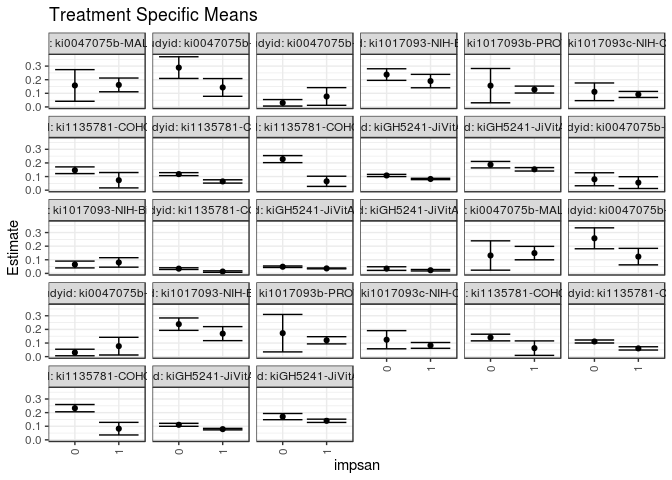

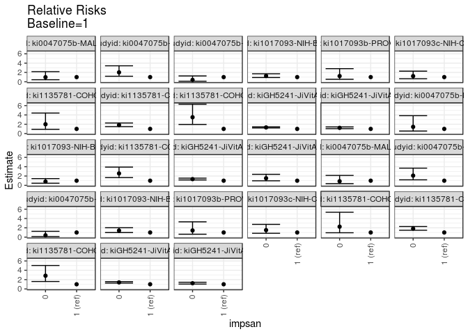

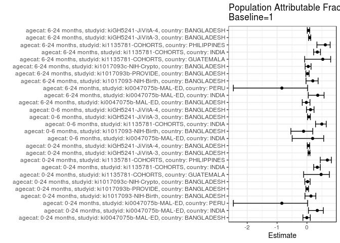

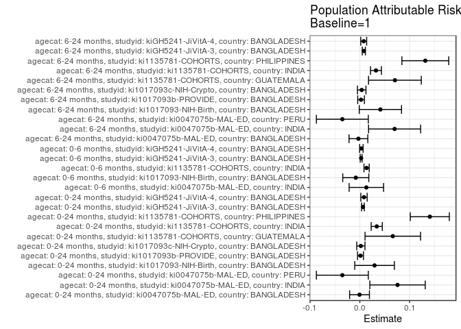

## Results Table

### Parameter: TSM

| agecat | studyid | country | intervention_level | baseline_level | estimate | ci_lower | ci_upper |
| --- | --- | --- | --- | --- | --- | --- | --- |
| 0-24 months | ki0047075b-MAL-ED | BANGLADESH | 1 | NA | 0.1617647 | 0.1111290 | 0.2124004 |
| 0-24 months | ki0047075b-MAL-ED | BANGLADESH | 0 | NA | 0.1578947 | 0.0417171 | 0.2740724 |
| 0-24 months | ki0047075b-MAL-ED | INDIA | 1 | NA | 0.1430976 | 0.0779708 | 0.2082244 |
| 0-24 months | ki0047075b-MAL-ED | INDIA | 0 | NA | 0.2886962 | 0.2090059 | 0.3683865 |
| 0-24 months | ki0047075b-MAL-ED | PERU | 1 | NA | 0.0769231 | 0.0120199 | 0.1418262 |
| 0-24 months | ki0047075b-MAL-ED | PERU | 0 | NA | 0.0303030 | 0.0063807 | 0.0542254 |
| 0-24 months | ki1017093-NIH-Birth | BANGLADESH | 1 | NA | 0.1899265 | 0.1406749 | 0.2391780 |
| 0-24 months | ki1017093-NIH-Birth | BANGLADESH | 0 | NA | 0.2376774 | 0.1949806 | 0.2803743 |
| 0-24 months | ki1017093b-PROVIDE | BANGLADESH | 1 | NA | 0.1276276 | 0.1022678 | 0.1529874 |
| 0-24 months | ki1017093b-PROVIDE | BANGLADESH | 0 | NA | 0.1562500 | 0.0303571 | 0.2821429 |
| 0-24 months | ki1017093c-NIH-Crypto | BANGLADESH | 1 | NA | 0.0916271 | 0.0695152 | 0.1137391 |
| 0-24 months | ki1017093c-NIH-Crypto | BANGLADESH | 0 | NA | 0.1111600 | 0.0464630 | 0.1758569 |
| 0-24 months | ki1135781-COHORTS | GUATEMALA | 1 | NA | 0.0731707 | 0.0167735 | 0.1295680 |
| 0-24 months | ki1135781-COHORTS | GUATEMALA | 0 | NA | 0.1462799 | 0.1216700 | 0.1708899 |
| 0-24 months | ki1135781-COHORTS | INDIA | 1 | NA | 0.0641192 | 0.0520092 | 0.0762293 |
| 0-24 months | ki1135781-COHORTS | INDIA | 0 | NA | 0.1178720 | 0.1069117 | 0.1288322 |
| 0-24 months | ki1135781-COHORTS | PHILIPPINES | 1 | NA | 0.0650587 | 0.0276838 | 0.1024337 |
| 0-24 months | ki1135781-COHORTS | PHILIPPINES | 0 | NA | 0.2280490 | 0.2021717 | 0.2539264 |
| 0-24 months | kiGH5241-JiVitA-3 | BANGLADESH | 1 | NA | 0.0822004 | 0.0775486 | 0.0868522 |
| 0-24 months | kiGH5241-JiVitA-3 | BANGLADESH | 0 | NA | 0.1080275 | 0.1000143 | 0.1160406 |
| 0-24 months | kiGH5241-JiVitA-4 | BANGLADESH | 1 | NA | 0.1530697 | 0.1403599 | 0.1657795 |
| 0-24 months | kiGH5241-JiVitA-4 | BANGLADESH | 0 | NA | 0.1872623 | 0.1633933 | 0.2111313 |
| 0-6 months | ki0047075b-MAL-ED | INDIA | 1 | NA | 0.0555556 | 0.0122621 | 0.0988490 |
| 0-6 months | ki0047075b-MAL-ED | INDIA | 0 | NA | 0.0800000 | 0.0323387 | 0.1276613 |
| 0-6 months | ki1017093-NIH-Birth | BANGLADESH | 1 | NA | 0.0804685 | 0.0456435 | 0.1152934 |
| 0-6 months | ki1017093-NIH-Birth | BANGLADESH | 0 | NA | 0.0652909 | 0.0403177 | 0.0902641 |
| 0-6 months | ki1135781-COHORTS | INDIA | 1 | NA | 0.0136839 | 0.0083809 | 0.0189869 |
| 0-6 months | ki1135781-COHORTS | INDIA | 0 | NA | 0.0349655 | 0.0286678 | 0.0412631 |
| 0-6 months | kiGH5241-JiVitA-3 | BANGLADESH | 1 | NA | 0.0366361 | 0.0334657 | 0.0398064 |
| 0-6 months | kiGH5241-JiVitA-3 | BANGLADESH | 0 | NA | 0.0490196 | 0.0436172 | 0.0544219 |
| 0-6 months | kiGH5241-JiVitA-4 | BANGLADESH | 1 | NA | 0.0232168 | 0.0178339 | 0.0285997 |
| 0-6 months | kiGH5241-JiVitA-4 | BANGLADESH | 0 | NA | 0.0353316 | 0.0219986 | 0.0486646 |
| 6-24 months | ki0047075b-MAL-ED | BANGLADESH | 1 | NA | 0.1492537 | 0.0998883 | 0.1986192 |
| 6-24 months | ki0047075b-MAL-ED | BANGLADESH | 0 | NA | 0.1315789 | 0.0238766 | 0.2392813 |
| 6-24 months | ki0047075b-MAL-ED | INDIA | 1 | NA | 0.1232345 | 0.0626833 | 0.1837857 |
| 6-24 months | ki0047075b-MAL-ED | INDIA | 0 | NA | 0.2578108 | 0.1809758 | 0.3346459 |
| 6-24 months | ki0047075b-MAL-ED | PERU | 1 | NA | 0.0769231 | 0.0120199 | 0.1418262 |
| 6-24 months | ki0047075b-MAL-ED | PERU | 0 | NA | 0.0303030 | 0.0063807 | 0.0542254 |
| 6-24 months | ki1017093-NIH-Birth | BANGLADESH | 1 | NA | 0.1690245 | 0.1176029 | 0.2204460 |
| 6-24 months | ki1017093-NIH-Birth | BANGLADESH | 0 | NA | 0.2382976 | 0.1927692 | 0.2838259 |
| 6-24 months | ki1017093b-PROVIDE | BANGLADESH | 1 | NA | 0.1200686 | 0.0936623 | 0.1464749 |
| 6-24 months | ki1017093b-PROVIDE | BANGLADESH | 0 | NA | 0.1724138 | 0.0348206 | 0.3100069 |
| 6-24 months | ki1017093c-NIH-Crypto | BANGLADESH | 1 | NA | 0.0824352 | 0.0609574 | 0.1039130 |
| 6-24 months | ki1017093c-NIH-Crypto | BANGLADESH | 0 | NA | 0.1242037 | 0.0574871 | 0.1909204 |
| 6-24 months | ki1135781-COHORTS | GUATEMALA | 1 | NA | 0.0625000 | 0.0094259 | 0.1155741 |
| 6-24 months | ki1135781-COHORTS | GUATEMALA | 0 | NA | 0.1402831 | 0.1158504 | 0.1647158 |
| 6-24 months | ki1135781-COHORTS | INDIA | 1 | NA | 0.0605196 | 0.0486544 | 0.0723847 |
| 6-24 months | ki1135781-COHORTS | INDIA | 0 | NA | 0.1111212 | 0.1001335 | 0.1221090 |
| 6-24 months | ki1135781-COHORTS | PHILIPPINES | 1 | NA | 0.0822320 | 0.0359534 | 0.1285105 |
| 6-24 months | ki1135781-COHORTS | PHILIPPINES | 0 | NA | 0.2328404 | 0.2061626 | 0.2595182 |
| 6-24 months | kiGH5241-JiVitA-3 | BANGLADESH | 1 | NA | 0.0787638 | 0.0733834 | 0.0841443 |
| 6-24 months | kiGH5241-JiVitA-3 | BANGLADESH | 0 | NA | 0.1105453 | 0.0996125 | 0.1214780 |
| 6-24 months | kiGH5241-JiVitA-4 | BANGLADESH | 1 | NA | 0.1399214 | 0.1278717 | 0.1519712 |
| 6-24 months | kiGH5241-JiVitA-4 | BANGLADESH | 0 | NA | 0.1709449 | 0.1481944 | 0.1936954 |

### Parameter: E(Y)

| agecat | studyid | country | intervention_level | baseline_level | estimate | ci_lower | ci_upper |
| --- | --- | --- | --- | --- | --- | --- | --- |
| 0-24 months | ki0047075b-MAL-ED | BANGLADESH | NA | NA | 0.1611570 | 0.1147371 | 0.2075770 |
| 0-24 months | ki0047075b-MAL-ED | INDIA | NA | NA | 0.2188841 | 0.1656771 | 0.2720911 |
| 0-24 months | ki0047075b-MAL-ED | PERU | NA | NA | 0.0418251 | 0.0175848 | 0.0660654 |
| 0-24 months | ki1017093-NIH-Birth | BANGLADESH | NA | NA | 0.2195513 | 0.1870467 | 0.2520558 |
| 0-24 months | ki1017093b-PROVIDE | BANGLADESH | NA | NA | 0.1289398 | 0.1040599 | 0.1538198 |
| 0-24 months | ki1017093c-NIH-Crypto | BANGLADESH | NA | NA | 0.0937082 | 0.0727959 | 0.1146204 |
| 0-24 months | ki1135781-COHORTS | GUATEMALA | NA | NA | 0.1394286 | 0.1164638 | 0.1623933 |
| 0-24 months | ki1135781-COHORTS | INDIA | NA | NA | 0.0981013 | 0.0901463 | 0.1060562 |
| 0-24 months | ki1135781-COHORTS | PHILIPPINES | NA | NA | 0.2057095 | 0.1827432 | 0.2286758 |
| 0-24 months | kiGH5241-JiVitA-3 | BANGLADESH | NA | NA | 0.0885196 | 0.0846439 | 0.0923953 |
| 0-24 months | kiGH5241-JiVitA-4 | BANGLADESH | NA | NA | 0.1614449 | 0.1501252 | 0.1727646 |
| 0-6 months | ki0047075b-MAL-ED | INDIA | NA | NA | 0.0686695 | 0.0361280 | 0.1012111 |
| 0-6 months | ki1017093-NIH-Birth | BANGLADESH | NA | NA | 0.0723473 | 0.0519719 | 0.0927227 |
| 0-6 months | ki1135781-COHORTS | INDIA | NA | NA | 0.0272886 | 0.0228458 | 0.0317313 |
| 0-6 months | kiGH5241-JiVitA-3 | BANGLADESH | NA | NA | 0.0393416 | 0.0368565 | 0.0418267 |
| 0-6 months | kiGH5241-JiVitA-4 | BANGLADESH | NA | NA | 0.0263831 | 0.0210411 | 0.0317252 |
| 6-24 months | ki0047075b-MAL-ED | BANGLADESH | NA | NA | 0.1464435 | 0.1015265 | 0.1913605 |
| 6-24 months | ki0047075b-MAL-ED | INDIA | NA | NA | 0.1931330 | 0.1423366 | 0.2439295 |
| 6-24 months | ki0047075b-MAL-ED | PERU | NA | NA | 0.0418251 | 0.0175848 | 0.0660654 |
| 6-24 months | ki1017093-NIH-Birth | BANGLADESH | NA | NA | 0.2103321 | 0.1759902 | 0.2446740 |
| 6-24 months | ki1017093b-PROVIDE | BANGLADESH | NA | NA | 0.1225490 | 0.0965478 | 0.1485502 |
| 6-24 months | ki1017093c-NIH-Crypto | BANGLADESH | NA | NA | 0.0862309 | 0.0656987 | 0.1067631 |
| 6-24 months | ki1135781-COHORTS | GUATEMALA | NA | NA | 0.1330222 | 0.1102724 | 0.1557720 |
| 6-24 months | ki1135781-COHORTS | INDIA | NA | NA | 0.0929723 | 0.0849408 | 0.1010038 |
| 6-24 months | ki1135781-COHORTS | PHILIPPINES | NA | NA | 0.2138365 | 0.1897378 | 0.2379351 |
| 6-24 months | kiGH5241-JiVitA-3 | BANGLADESH | NA | NA | 0.0868080 | 0.0821493 | 0.0914667 |
| 6-24 months | kiGH5241-JiVitA-4 | BANGLADESH | NA | NA | 0.1477315 | 0.1371478 | 0.1583151 |

### Parameter: RR

| agecat | studyid | country | intervention_level | baseline_level | estimate | ci_lower | ci_upper |
| --- | --- | --- | --- | --- | --- | --- | --- |
| 0-24 months | ki0047075b-MAL-ED | BANGLADESH | 1 | 1 | 1.0000000 | 1.0000000 | 1.000000 |
| 0-24 months | ki0047075b-MAL-ED | BANGLADESH | 0 | 1 | 0.9760766 | 0.4387519 | 2.171445 |
| 0-24 months | ki0047075b-MAL-ED | INDIA | 1 | 1 | 1.0000000 | 1.0000000 | 1.000000 |
| 0-24 months | ki0047075b-MAL-ED | INDIA | 0 | 1 | 2.0174780 | 1.1888968 | 3.423525 |
| 0-24 months | ki0047075b-MAL-ED | PERU | 1 | 1 | 1.0000000 | 1.0000000 | 1.000000 |
| 0-24 months | ki0047075b-MAL-ED | PERU | 0 | 1 | 0.3939394 | 0.1240553 | 1.250961 |
| 0-24 months | ki1017093-NIH-Birth | BANGLADESH | 1 | 1 | 1.0000000 | 1.0000000 | 1.000000 |
| 0-24 months | ki1017093-NIH-Birth | BANGLADESH | 0 | 1 | 1.2514182 | 0.9139249 | 1.713540 |
| 0-24 months | ki1017093b-PROVIDE | BANGLADESH | 1 | 1 | 1.0000000 | 1.0000000 | 1.000000 |
| 0-24 months | ki1017093b-PROVIDE | BANGLADESH | 0 | 1 | 1.2242647 | 0.5339174 | 2.807221 |
| 0-24 months | ki1017093c-NIH-Crypto | BANGLADESH | 1 | 1 | 1.0000000 | 1.0000000 | 1.000000 |
| 0-24 months | ki1017093c-NIH-Crypto | BANGLADESH | 0 | 1 | 1.2131774 | 0.6464934 | 2.276588 |
| 0-24 months | ki1135781-COHORTS | GUATEMALA | 1 | 1 | 1.0000000 | 1.0000000 | 1.000000 |
| 0-24 months | ki1135781-COHORTS | GUATEMALA | 0 | 1 | 1.9991593 | 0.9082974 | 4.400142 |
| 0-24 months | ki1135781-COHORTS | INDIA | 1 | 1 | 1.0000000 | 1.0000000 | 1.000000 |
| 0-24 months | ki1135781-COHORTS | INDIA | 0 | 1 | 1.8383253 | 1.4904766 | 2.267355 |
| 0-24 months | ki1135781-COHORTS | PHILIPPINES | 1 | 1 | 1.0000000 | 1.0000000 | 1.000000 |
| 0-24 months | ki1135781-COHORTS | PHILIPPINES | 0 | 1 | 3.5052805 | 1.9528640 | 6.291780 |
| 0-24 months | kiGH5241-JiVitA-3 | BANGLADESH | 1 | 1 | 1.0000000 | 1.0000000 | 1.000000 |
| 0-24 months | kiGH5241-JiVitA-3 | BANGLADESH | 0 | 1 | 1.3141968 | 1.2039604 | 1.434527 |
| 0-24 months | kiGH5241-JiVitA-4 | BANGLADESH | 1 | 1 | 1.0000000 | 1.0000000 | 1.000000 |
| 0-24 months | kiGH5241-JiVitA-4 | BANGLADESH | 0 | 1 | 1.2233792 | 1.0518396 | 1.422894 |
| 0-6 months | ki0047075b-MAL-ED | INDIA | 1 | 1 | 1.0000000 | 1.0000000 | 1.000000 |
| 0-6 months | ki0047075b-MAL-ED | INDIA | 0 | 1 | 1.4400000 | 0.5399472 | 3.840376 |
| 0-6 months | ki1017093-NIH-Birth | BANGLADESH | 1 | 1 | 1.0000000 | 1.0000000 | 1.000000 |
| 0-6 months | ki1017093-NIH-Birth | BANGLADESH | 0 | 1 | 0.8113847 | 0.4558502 | 1.444214 |
| 0-6 months | ki1135781-COHORTS | INDIA | 1 | 1 | 1.0000000 | 1.0000000 | 1.000000 |
| 0-6 months | ki1135781-COHORTS | INDIA | 0 | 1 | 2.5552257 | 1.6666185 | 3.917620 |
| 0-6 months | kiGH5241-JiVitA-3 | BANGLADESH | 1 | 1 | 1.0000000 | 1.0000000 | 1.000000 |
| 0-6 months | kiGH5241-JiVitA-3 | BANGLADESH | 0 | 1 | 1.3380136 | 1.1617595 | 1.541008 |
| 0-6 months | kiGH5241-JiVitA-4 | BANGLADESH | 1 | 1 | 1.0000000 | 1.0000000 | 1.000000 |
| 0-6 months | kiGH5241-JiVitA-4 | BANGLADESH | 0 | 1 | 1.5218126 | 0.9785715 | 2.366627 |
| 6-24 months | ki0047075b-MAL-ED | BANGLADESH | 1 | 1 | 1.0000000 | 1.0000000 | 1.000000 |
| 6-24 months | ki0047075b-MAL-ED | BANGLADESH | 0 | 1 | 0.8815789 | 0.3646285 | 2.131434 |
| 6-24 months | ki0047075b-MAL-ED | INDIA | 1 | 1 | 1.0000000 | 1.0000000 | 1.000000 |
| 6-24 months | ki0047075b-MAL-ED | INDIA | 0 | 1 | 2.0920341 | 1.1847041 | 3.694261 |
| 6-24 months | ki0047075b-MAL-ED | PERU | 1 | 1 | 1.0000000 | 1.0000000 | 1.000000 |
| 6-24 months | ki0047075b-MAL-ED | PERU | 0 | 1 | 0.3939394 | 0.1240553 | 1.250961 |
| 6-24 months | ki1017093-NIH-Birth | BANGLADESH | 1 | 1 | 1.0000000 | 1.0000000 | 1.000000 |
| 6-24 months | ki1017093-NIH-Birth | BANGLADESH | 0 | 1 | 1.4098406 | 0.9856064 | 2.016678 |
| 6-24 months | ki1017093b-PROVIDE | BANGLADESH | 1 | 1 | 1.0000000 | 1.0000000 | 1.000000 |
| 6-24 months | ki1017093b-PROVIDE | BANGLADESH | 0 | 1 | 1.4359606 | 0.6275349 | 3.285845 |
| 6-24 months | ki1017093c-NIH-Crypto | BANGLADESH | 1 | 1 | 1.0000000 | 1.0000000 | 1.000000 |
| 6-24 months | ki1017093c-NIH-Crypto | BANGLADESH | 0 | 1 | 1.5066828 | 0.8290119 | 2.738312 |
| 6-24 months | ki1135781-COHORTS | GUATEMALA | 1 | 1 | 1.0000000 | 1.0000000 | 1.000000 |
| 6-24 months | ki1135781-COHORTS | GUATEMALA | 0 | 1 | 2.2445302 | 0.9433052 | 5.340706 |
| 6-24 months | ki1135781-COHORTS | INDIA | 1 | 1 | 1.0000000 | 1.0000000 | 1.000000 |
| 6-24 months | ki1135781-COHORTS | INDIA | 0 | 1 | 1.8361214 | 1.4755486 | 2.284806 |
| 6-24 months | ki1135781-COHORTS | PHILIPPINES | 1 | 1 | 1.0000000 | 1.0000000 | 1.000000 |
| 6-24 months | ki1135781-COHORTS | PHILIPPINES | 0 | 1 | 2.8315073 | 1.5951781 | 5.026043 |
| 6-24 months | kiGH5241-JiVitA-3 | BANGLADESH | 1 | 1 | 1.0000000 | 1.0000000 | 1.000000 |
| 6-24 months | kiGH5241-JiVitA-3 | BANGLADESH | 0 | 1 | 1.4035030 | 1.2509452 | 1.574666 |
| 6-24 months | kiGH5241-JiVitA-4 | BANGLADESH | 1 | 1 | 1.0000000 | 1.0000000 | 1.000000 |
| 6-24 months | kiGH5241-JiVitA-4 | BANGLADESH | 0 | 1 | 1.2217203 | 1.0416659 | 1.432898 |

### Parameter: PAR

| agecat | studyid | country | intervention_level | baseline_level | estimate | ci_lower | ci_upper |
| --- | --- | --- | --- | --- | --- | --- | --- |
| 0-24 months | ki0047075b-MAL-ED | BANGLADESH | 1 | NA | -0.0006077 | -0.0205087 | 0.0192933 |
| 0-24 months | ki0047075b-MAL-ED | INDIA | 1 | NA | 0.0757865 | 0.0201067 | 0.1314664 |
| 0-24 months | ki0047075b-MAL-ED | PERU | 1 | NA | -0.0350980 | -0.0872308 | 0.0170348 |
| 0-24 months | ki1017093-NIH-Birth | BANGLADESH | 1 | NA | 0.0296248 | -0.0101894 | 0.0694390 |
| 0-24 months | ki1017093b-PROVIDE | BANGLADESH | 1 | NA | 0.0013122 | -0.0045921 | 0.0072165 |
| 0-24 months | ki1017093c-NIH-Crypto | BANGLADESH | 1 | NA | 0.0020810 | -0.0061906 | 0.0103526 |
| 0-24 months | ki1135781-COHORTS | GUATEMALA | 1 | NA | 0.0662578 | 0.0104736 | 0.1220421 |
| 0-24 months | ki1135781-COHORTS | INDIA | 1 | NA | 0.0339821 | 0.0227894 | 0.0451747 |
| 0-24 months | ki1135781-COHORTS | PHILIPPINES | 1 | NA | 0.1406508 | 0.1014364 | 0.1798652 |
| 0-24 months | kiGH5241-JiVitA-3 | BANGLADESH | 1 | NA | 0.0063192 | 0.0036818 | 0.0089566 |
| 0-24 months | kiGH5241-JiVitA-4 | BANGLADESH | 1 | NA | 0.0083752 | 0.0020181 | 0.0147323 |
| 0-6 months | ki0047075b-MAL-ED | INDIA | 1 | NA | 0.0131140 | -0.0214650 | 0.0476929 |
| 0-6 months | ki1017093-NIH-Birth | BANGLADESH | 1 | NA | -0.0081212 | -0.0343093 | 0.0180669 |
| 0-6 months | ki1135781-COHORTS | INDIA | 1 | NA | 0.0136047 | 0.0083497 | 0.0188597 |
| 0-6 months | kiGH5241-JiVitA-3 | BANGLADESH | 1 | NA | 0.0027055 | 0.0008187 | 0.0045923 |
| 0-6 months | kiGH5241-JiVitA-4 | BANGLADESH | 1 | NA | 0.0031664 | -0.0003005 | 0.0066332 |
| 6-24 months | ki0047075b-MAL-ED | BANGLADESH | 1 | NA | -0.0028102 | -0.0216654 | 0.0160450 |
| 6-24 months | ki0047075b-MAL-ED | INDIA | 1 | NA | 0.0698985 | 0.0176016 | 0.1221954 |
| 6-24 months | ki0047075b-MAL-ED | PERU | 1 | NA | -0.0350980 | -0.0872308 | 0.0170348 |
| 6-24 months | ki1017093-NIH-Birth | BANGLADESH | 1 | NA | 0.0413076 | -0.0011689 | 0.0837841 |
| 6-24 months | ki1017093b-PROVIDE | BANGLADESH | 1 | NA | 0.0024804 | -0.0042168 | 0.0091776 |
| 6-24 months | ki1017093c-NIH-Crypto | BANGLADESH | 1 | NA | 0.0037956 | -0.0047555 | 0.0123468 |
| 6-24 months | ki1135781-COHORTS | GUATEMALA | 1 | NA | 0.0705222 | 0.0175268 | 0.1235175 |
| 6-24 months | ki1135781-COHORTS | INDIA | 1 | NA | 0.0324528 | 0.0214919 | 0.0434136 |
| 6-24 months | ki1135781-COHORTS | PHILIPPINES | 1 | NA | 0.1316045 | 0.0845518 | 0.1786572 |
| 6-24 months | kiGH5241-JiVitA-3 | BANGLADESH | 1 | NA | 0.0080441 | 0.0049036 | 0.0111847 |
| 6-24 months | kiGH5241-JiVitA-4 | BANGLADESH | 1 | NA | 0.0078100 | 0.0018684 | 0.0137517 |

### Parameter: PAF

| agecat | studyid | country | intervention_level | baseline_level | estimate | ci_lower | ci_upper |
| --- | --- | --- | --- | --- | --- | --- | --- |
| 0-24 months | ki0047075b-MAL-ED | BANGLADESH | 1 | NA | -0.0037707 | -0.1351730 | 0.1124210 |
| 0-24 months | ki0047075b-MAL-ED | INDIA | 1 | NA | 0.3462404 | 0.0503352 | 0.5499447 |
| 0-24 months | ki0047075b-MAL-ED | PERU | 1 | NA | -0.8391608 | -2.4633938 | 0.0233532 |
| 0-24 months | ki1017093-NIH-Birth | BANGLADESH | 1 | NA | 0.1349335 | -0.0661185 | 0.2980705 |
| 0-24 months | ki1017093b-PROVIDE | BANGLADESH | 1 | NA | 0.0101768 | -0.0366587 | 0.0548963 |
| 0-24 months | ki1017093c-NIH-Crypto | BANGLADESH | 1 | NA | 0.0222075 | -0.0700580 | 0.1065175 |
| 0-24 months | ki1135781-COHORTS | GUATEMALA | 1 | NA | 0.4752099 | -0.1111802 | 0.7521513 |
| 0-24 months | ki1135781-COHORTS | INDIA | 1 | NA | 0.3463978 | 0.2255384 | 0.4483963 |
| 0-24 months | ki1135781-COHORTS | PHILIPPINES | 1 | NA | 0.6837350 | 0.4463199 | 0.8193478 |
| 0-24 months | kiGH5241-JiVitA-3 | BANGLADESH | 1 | NA | 0.0713879 | 0.0409945 | 0.1008180 |
| 0-24 months | kiGH5241-JiVitA-4 | BANGLADESH | 1 | NA | 0.0518764 | 0.0116807 | 0.0904373 |
| 0-6 months | ki0047075b-MAL-ED | INDIA | 1 | NA | 0.1909722 | -0.4941878 | 0.5619520 |
| 0-6 months | ki1017093-NIH-Birth | BANGLADESH | 1 | NA | -0.1122534 | -0.5373989 | 0.1953242 |
| 0-6 months | ki1135781-COHORTS | INDIA | 1 | NA | 0.4985481 | 0.2884311 | 0.6466204 |
| 0-6 months | kiGH5241-JiVitA-3 | BANGLADESH | 1 | NA | 0.0687694 | 0.0191936 | 0.1158394 |
| 0-6 months | kiGH5241-JiVitA-4 | BANGLADESH | 1 | NA | 0.1200144 | -0.0153827 | 0.2373569 |
| 6-24 months | ki0047075b-MAL-ED | BANGLADESH | 1 | NA | -0.0191898 | -0.1563308 | 0.1016863 |
| 6-24 months | ki0047075b-MAL-ED | INDIA | 1 | NA | 0.3619190 | 0.0444750 | 0.5739019 |
| 6-24 months | ki0047075b-MAL-ED | PERU | 1 | NA | -0.8391608 | -2.4633938 | 0.0233532 |
| 6-24 months | ki1017093-NIH-Birth | BANGLADESH | 1 | NA | 0.1963925 | -0.0316717 | 0.3740402 |
| 6-24 months | ki1017093b-PROVIDE | BANGLADESH | 1 | NA | 0.0202401 | -0.0358324 | 0.0732773 |
| 6-24 months | ki1017093c-NIH-Crypto | BANGLADESH | 1 | NA | 0.0440173 | -0.0599822 | 0.1378129 |
| 6-24 months | ki1135781-COHORTS | GUATEMALA | 1 | NA | 0.5301535 | -0.0763444 | 0.7949023 |
| 6-24 months | ki1135781-COHORTS | INDIA | 1 | NA | 0.3490584 | 0.2242536 | 0.4537842 |
| 6-24 months | ki1135781-COHORTS | PHILIPPINES | 1 | NA | 0.6154446 | 0.3346779 | 0.7777274 |
| 6-24 months | kiGH5241-JiVitA-3 | BANGLADESH | 1 | NA | 0.0926659 | 0.0558640 | 0.1280333 |
| 6-24 months | kiGH5241-JiVitA-4 | BANGLADESH | 1 | NA | 0.0528663 | 0.0116617 | 0.0923531 |